# Explore Teaching Lab’s Data

# Survey Links

Please verify if the following links are available in Moodle and slide decks, and add if necessary.

- **Attendance list**: https://tinyurl.com/TL-attend
- **Diagnostic Educator Survey. We are finding that we have higher completion rates when time is given in the first session to complete this**. It’s taking participants 5 minutes on average to complete, per Survey Monkey metrics.
  - Link: https://www.surveymonkey.com/r/diagnosticSY21-22
- **Short knowledge assessments to be taken during the first and last session of PL**. Knowledge assessments are taking around 5 min, per Survey Monkey metrics.
  - Please find the link to your course here, under the tab “Knowledge Assessment Links”. We are drafting these in order of PL courses being implemented, so not all are ready yet.
- **End-of-Session Participant Feedback Survey to be taken after every PL session**, except the final session (e.g., if there are 5 sessions, use this for Sessions #1-4). Please remind participants of which course they are taking. It’s taking 2 min, per Survey Monkey metrics.
  - Link: https://www.surveymonkey.com/r/TLendofsession
- **End-of-Course Participant Feedback Survey to be taken after the final PL session** (e.g., if there are 5 sessions, use this for Session #5). Please remind participants of which course they are taking. It’s taking 4 min, per Survey Monkey metrics.
  - Link: https://www.surveymonkey.com/r/TLendofcourse

# Active Dashboards

Row1

Row2

Row3

Row4

**End of Course Surveys 2021-2022**

**End of Session Surveys 2021-2022**

**Diagnostic Responses per Partner**

**Race and Culture Internal Surveys**

[figure not shown]

[figure not shown]

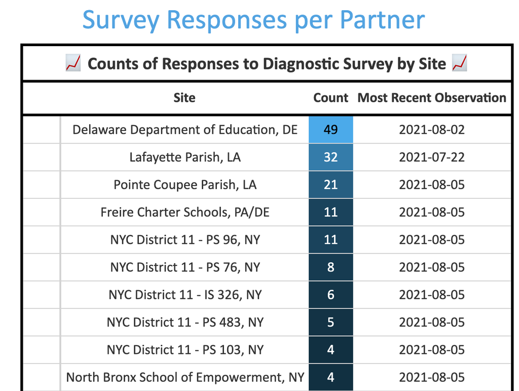

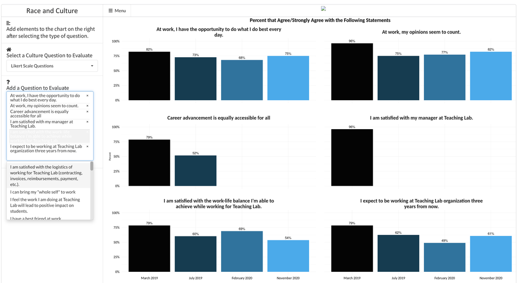

# Miscellaneous

© Teaching Lab, 2021

*support@teachinglab.org*